# Covid-19 and regional deprivation in England

Dr Matthew Gwynfryn Thomas

20/02/2021

## Deaths and deprivation in Local Authorities

Overall, there’s a strong association between Covid-19 death rates and deprivation - more deprived Local Authorities have higher death rates:

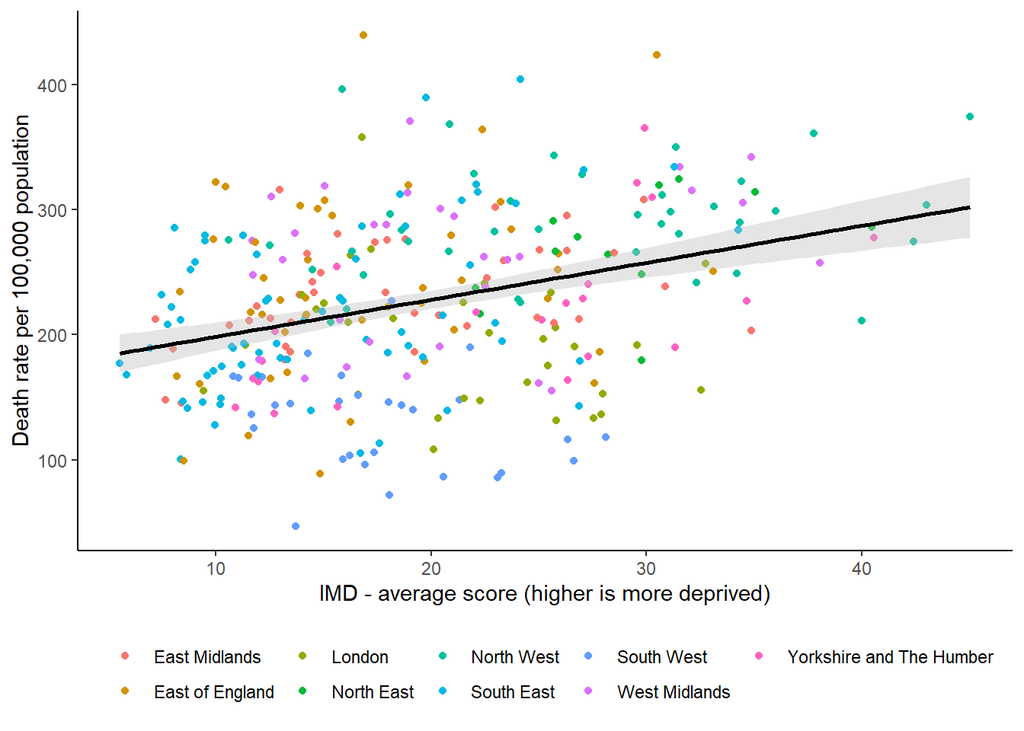

Generally, Covid-19 death rates are higher in more deprived Local Authorities, regardless of region - except in London and the South West - although the strength of the association varies from place to place:

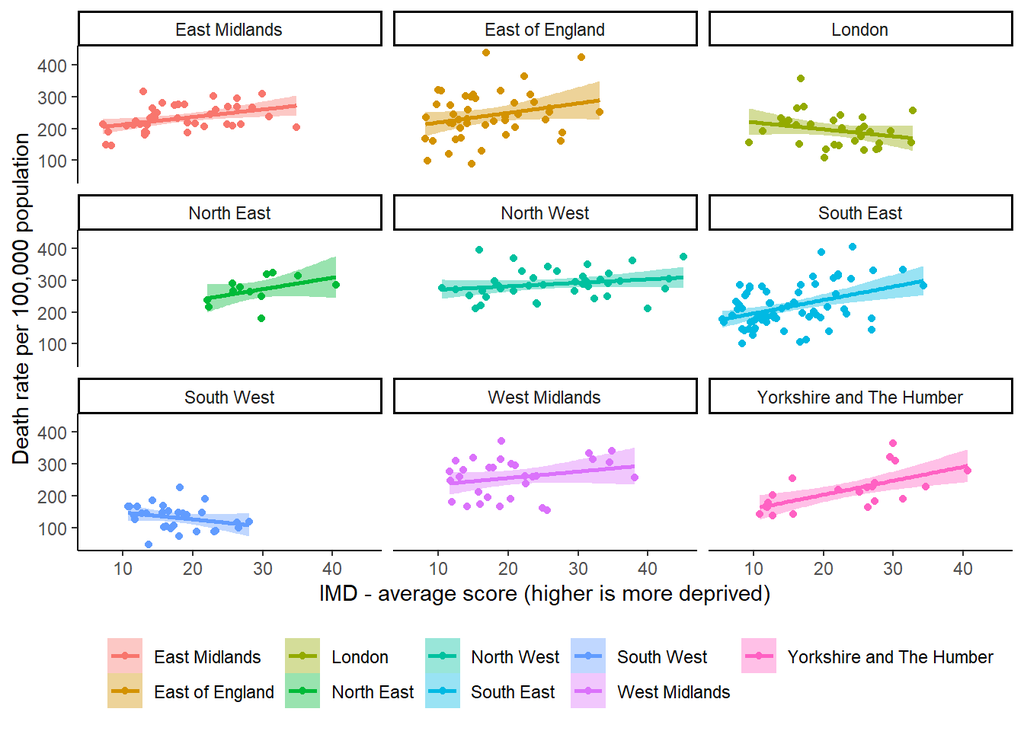

And the pattern is broadly the same when looking at proportions of the population who live within the nation’s most deprived neighbourhoods, rather than just the Local Authorities’ average deprivation scores:

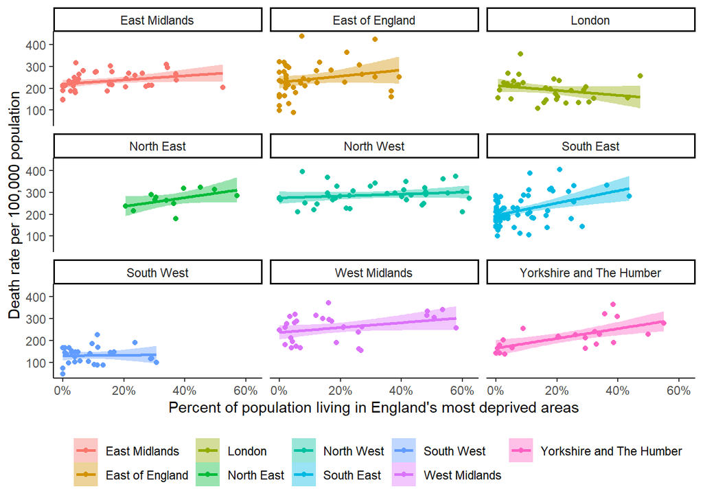

## MSOA-level deprivation

Similarly, death rates tend to be higher in more deprived neighbourhoods, although the association isn’t as strong compared to looking at Local Authorities:

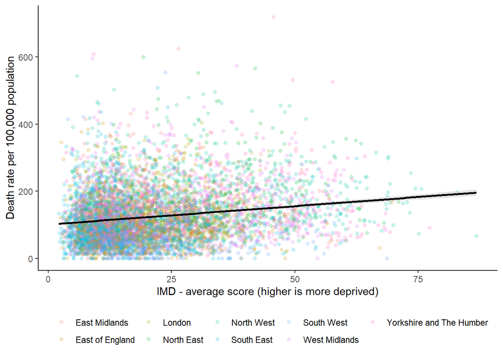

However, when looking at neighbourhood-level deprivation by region, the association between death rates and deprivation seems a lot weaker:

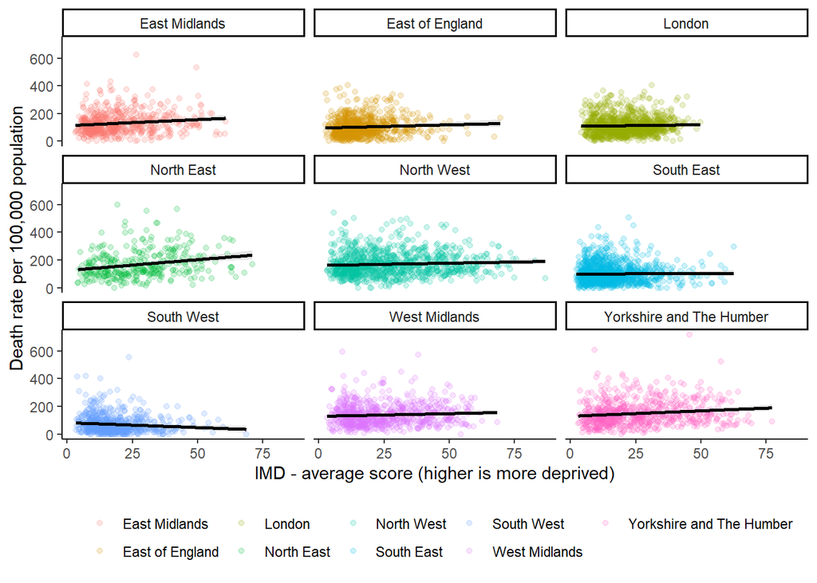

And this pattern remains similar when using other summary measures of deprivation, such as the proportion of the population who live within the nation’s most deprived neighbourhoods…

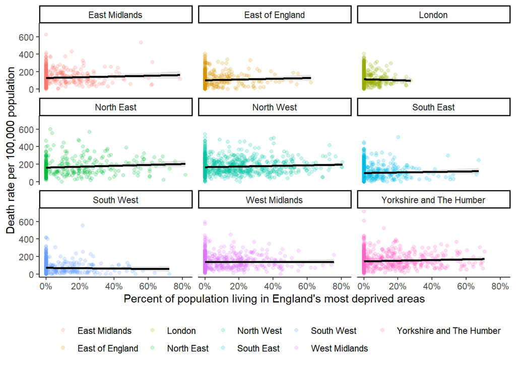

… or the proportion of LSOAs within an MSOA which are among the nation’s most deprived:

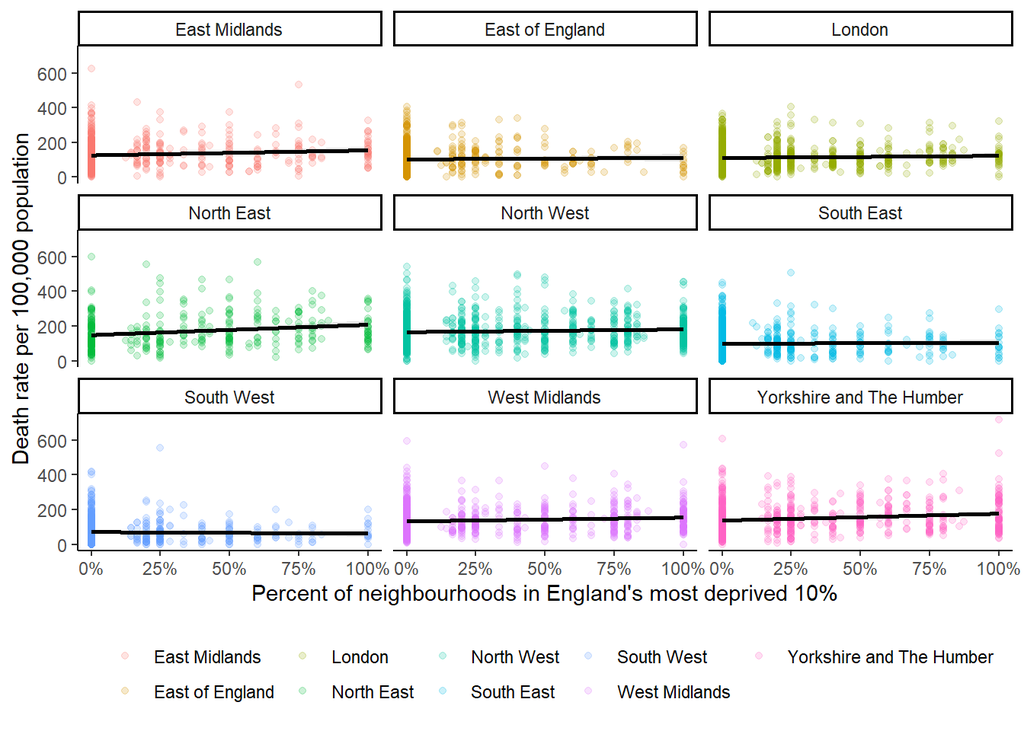

So although more deprived areas have higher death rates on average at a national level and Local Authority level, the picture becomes a bit blurred when looking at neighbourhoods.

## Modelling regional deprivation and death rates

For Local Authorities, higher deprivation is associated with higher death rates in the East of England, South East, West Midlands, and Yorkshire and the Humber.

At MSOA-level, higher deprivation is associated with higher death rates in the North East, North West, and Yorkshire and the Humber.

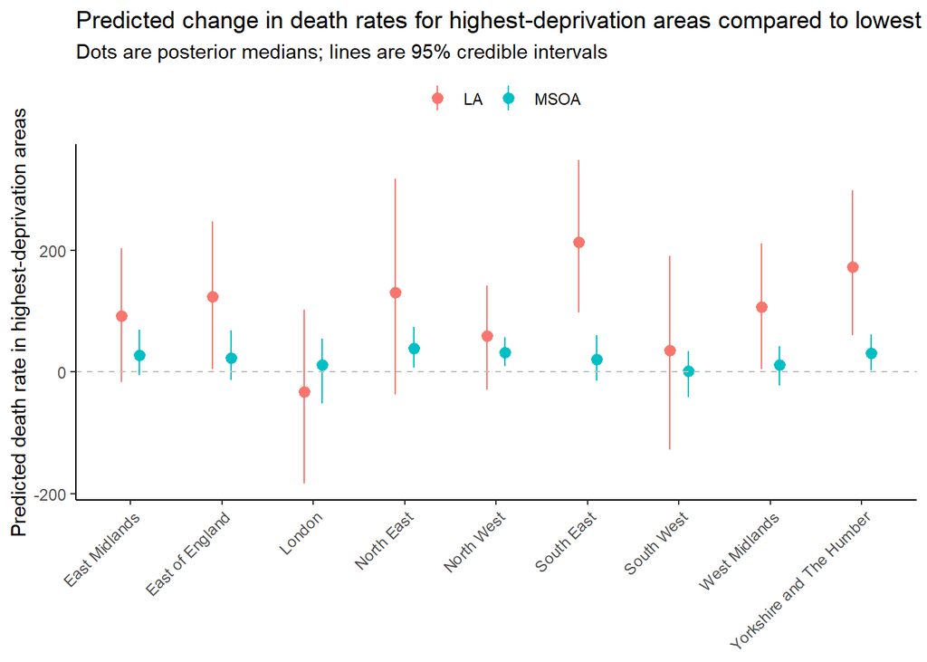

These results are from a Bayesian multilevel regressions modelling how extent of deprivation predicts Covid-19 death rates in LAs and MSOAs, with varying intercepts and varying slopes for regions.

## Which measure of deprivation you use matters

The results above are based on the proportion of the population who live within the nation’s most deprived neighbourhoods. If we instead model death rates using average deprivation scores, a slightly different picture emerges. Now there is also a statistically significant association between deprivation and death rates in the East and West Midlands for MSOAs. At LA-level, significant associations are found in the East Midlands, Yorkshire and the Humber, as well as the East and South East.

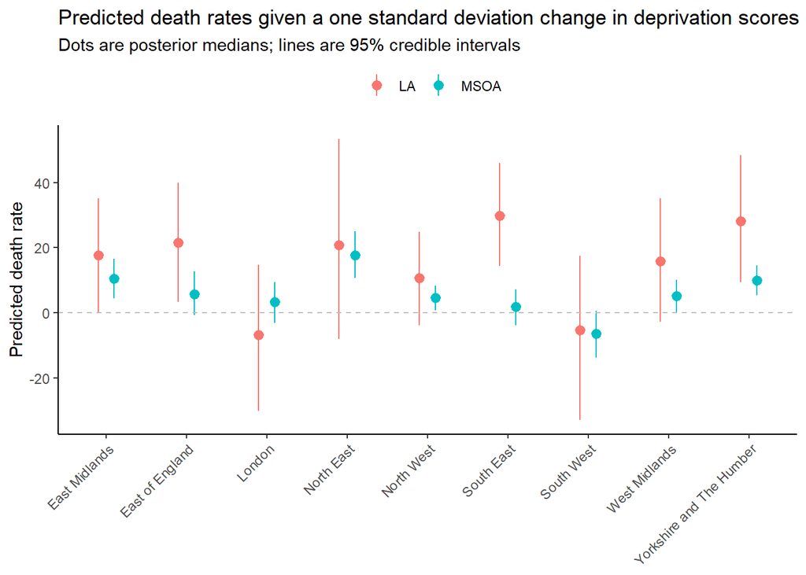